# AMEN to Replication: Networks in IR

## Purpose

- Why are we meeting during Thanksgiving weekend…I didn't realize the date and none of you objected :)
- Anyhow…we are here to talk about conducting a meta-analysis of dyadic studies in political science using the Additive and Multiplicative Effects Model for Networks (AMEN)
- What I hope we find from this project is that using standard GLM approaches on dyadic data produces
  - biased estimates of the effect of independent variables
  - uncalibrated confidence intervals
  - and poor predictive performance.
- Anticipated outputs:
  - One big meta-analysis piece in which we show the items in the list above to be true on average
  - **After** big project is done, a number of small replication pieces
  - New disciples to spread the gospel

## Outline

- **Brief** background discussion of AMEN based on [Hoff's vignette](https://arxiv.org/pdf/1506.08237v1.pdf) and a [joint piece with me and Mike](https://arxiv.org/pdf/1611.00460v1.pdf)
- Example application of AMEN, where we will
  - Discuss how to structure input data
  - Extract and interpret model results
  - Conduct out-of-sample performance on longitudinal networks
- Discuss project management

## Dyadic data

- Any dataset in which the unit of observation is characterized by a pair of actors
  - MIDs
  - International economic agreements (PTAs, BITs)
  - Alliances (NATO)
  - Trade flows

## What makes dyadic data special

- Formation of a tie between any pair of actors is **not necessarily** independent of other ties
  - This is true for bilateral and multilateral events
- Why?

## Actors are part of a system … a network

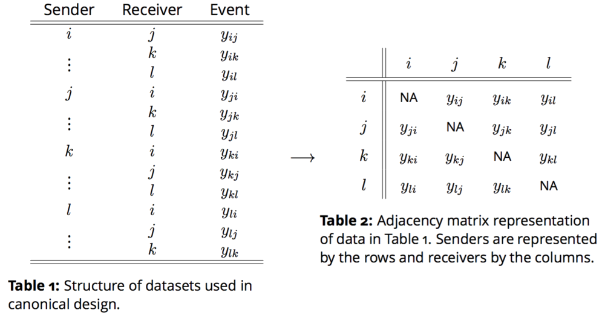

## Flavors of dependencies

- First order dependence
  - Often will find significant heterogeneity in activity levels across nodes
- Second order dependence
  - Reciprocity: Event sent from i \(\rightarrow\) j is likely related to an event sent from j \(\rightarrow\) i

## What to do: Social Relations Model

\[ \begin{aligned} y_{ij} &= \color{red}{\mu} + \color{red}{e_{ij}} \\ e_{ij} &= a_{i} + b_{j} + \epsilon_{ij} \\ \{ (a_{1}, b_{1}), \ldots, (a_{n}, b_{n}) \} &\sim N(0,\Sigma_{ab}) \\ \{ (\epsilon_{ij}, \epsilon_{ji}) : \; i \neq j\} &\sim N(0,\Sigma_{\epsilon}), \text{ where } \\ \Sigma_{ab} = \begin{pmatrix} \sigma_{a}^{2} & \sigma_{ab} \\ \sigma_{ab} & \sigma_{b}^2 \end{pmatrix} \;\;\;\;\; &\Sigma_{\epsilon} = \sigma_{\epsilon}^{2} \begin{pmatrix} 1 & \rho \\ \rho & 1 \end{pmatrix} \end{aligned} \]

- \(\mu\) baseline measure of network activity, for the purpose of regression we turn this into \(\beta^{T}X\)
- \(e_{ij}\) residual variation that we will use the SRM to decompose

## What to do: Social Relations Model

\[ \begin{aligned} y_{ij} &= \mu + e_{ij} \\ e_{ij} &= \color{red}{a_{i} + b_{j}} + \epsilon_{ij} \\ \color{red}{\{ (a_{1}, b_{1}), \ldots, (a_{n}, b_{n}) \}} &\sim N(0,\Sigma_{ab}) \\ \{ (\epsilon_{ij}, \epsilon_{ji}) : \; i \neq j\} &\sim N(0,\Sigma_{\epsilon}), \text{ where } \\ \Sigma_{ab} = \begin{pmatrix} \sigma_{a}^{2} & \sigma_{ab} \\ \sigma_{ab} & \sigma_{b}^2 \end{pmatrix} \;\;\;\;\; &\Sigma_{\epsilon} = \sigma_{\epsilon}^{2} \begin{pmatrix} 1 & \rho \\ \rho & 1 \end{pmatrix} \end{aligned} \]

- row/sender effect (\(a_{i}\)) & column/receiver effect (\(b_{j}\))
- Modeled jointly to account for correlation in how active an actor is in sending and receiving ties

## What to do: Social Relations Model

\[ \begin{aligned} y_{ij} &= \mu + e_{ij} \\ e_{ij} &= a_{i} + b_{j} + \epsilon_{ij} \\ \{ (a_{1}, b_{1}), \ldots, (a_{n}, b_{n}) \} &\sim N(0,\color{red}{\Sigma_{ab}}) \\ \{ (\epsilon_{ij}, \epsilon_{ji}) : \; i \neq j\} &\sim N(0,\Sigma_{\epsilon}), \text{ where } \\ \color{red}{\Sigma_{ab}} = \begin{pmatrix} \sigma_{a}^{2} & \sigma_{ab} \\ \sigma_{ab} & \sigma_{b}^2 \end{pmatrix} \;\;\;\;\; &\Sigma_{\epsilon} = \sigma_{\epsilon}^{2} \begin{pmatrix} 1 & \rho \\ \rho & 1 \end{pmatrix} \end{aligned} \]

- \(\sigma_{a}^{2}\) and \(\sigma_{b}^{2}\) capture heterogeneity in the row and column means
- \(\sigma_{ab}\) describes the linear relationship between these two effects (i.e., whether actors who send [receive] a lot of ties also receive [send] a lot of ties)

## What to do: Social Relations Model

\[ \begin{aligned} y_{ij} &= \mu + e_{ij} \\ e_{ij} &= a_{i} + b_{j} + \color{red}{\epsilon_{ij}} \\ \{ (a_{1}, b_{1}), \ldots, (a_{n}, b_{n}) \} &\sim N(0,\Sigma_{ab}) \\ \color{red}{\{ (\epsilon_{ij}, \epsilon_{ji}) : \; i \neq j\}} &\sim N(0,\color{red}{\Sigma_{\epsilon}}), \text{ where } \\ \Sigma_{ab} = \begin{pmatrix} \sigma_{a}^{2} & \sigma_{ab} \\ \sigma_{ab} & \sigma_{b}^2 \end{pmatrix} \;\;\;\;\; & \color{red}{\Sigma_{\epsilon}} = \sigma_{\epsilon}^{2} \begin{pmatrix} 1 & \rho \\ \rho & 1 \end{pmatrix} \end{aligned} \]

- \(\epsilon_{ij}\) captures the within dyad effect
- Second-order dependencies are described by \(\sigma_{\epsilon}^{2}\)
- Within dyad correlation, aka reciprocity, represented by \(\rho\)

## Network level dependencies

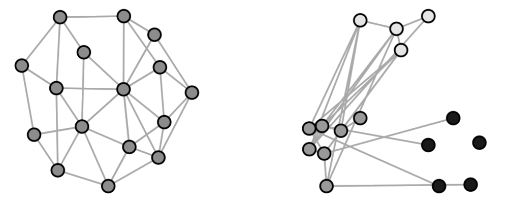

- Homophily
- Stochastic equivalence

## Latent variable models for networks

\[ \begin{aligned} \text{Latent class model} \\ &\alpha(u_{i}, u_{j}) = m_{u_{i}, u_{j}} \\ &u_{i} \in \{1, \ldots, K \}, \; i \in \{1,\ldots, n\} \\ &M \text{ a } K \times K \text{ symmetric matrix} \\ \text{Latent distance model} \\ &\alpha(\textbf{u}_{i}, \textbf{u}_{j}) = -|\textbf{u}_{i} - \textbf{u}_{j}| \\ &\textbf{u}_{i} \in \mathbb{R}^{K}, \; i \in \{1, \ldots, n \} \\ \text{Latent factor model} \\ &\alpha(\textbf{u}_{i}, \textbf{u}_{j}) = \textbf{u}_{i}^{T} \Lambda \textbf{u}_{j} \\ &\textbf{u}_{i} \in \mathbb{R}^{K}, \; i \in \{1, \ldots, n \} \\ &\Lambda \text{ a } K \times K \text{ diagonal matrix} \end{aligned} \]

## Our preferred approach

\[ \begin{aligned} \text{Latent class model} \\ &\alpha(u_{i}, u_{j}) = m_{u_{i}, u_{j}} \\ &u_{i} \in \{1, \ldots, K \}, \; i \in \{1,\ldots, n\} \\ &M \text{ a } K \times K \text{ symmetric matrix} \\ \text{Latent distance model} \\ &\alpha(\textbf{u}_{i}, \textbf{u}_{j}) = -|\textbf{u}_{i} - \textbf{u}_{j}| \\ &\textbf{u}_{i} \in \mathbb{R}^{K}, \; i \in \{1, \ldots, n \} \\ \color{red}{\text{Latent factor model}} \\ &\alpha(\textbf{u}_{i}, \textbf{u}_{j}) = \textbf{u}_{i}^{T} \Lambda \textbf{u}_{j} \\ &\textbf{u}_{i} \in \mathbb{R}^{K}, \; i \in \{1, \ldots, n \} \\ &\Lambda \text{ a } K \times K \text{ diagonal matrix} \end{aligned} \]

## Putting it all together: AME

\[ \begin{aligned} y_{ij} &= g(\theta_{ij}) \\ &\theta_{ij} = \beta^{T} \mathbf{X}_{ij} + e_{ij} \\ &e_{ij} = a_{i} + b_{j} + \epsilon_{ij} + \textbf{u}_{i}^{T} \textbf{D} \textbf{v}_{j} \\ \end{aligned} \]

- \(a_{i} + b_{j} + \epsilon_{ij}\), are additive random effects and account for sender, receiver, and within-dyad dependence
- multiplicative effects, \(\textbf{u}_{i}^{T} \textbf{D} \textbf{v}_{j}\), capture higher-order dependence patterns that are left over in \(\theta\) after accounting for any known covariate information

## Benefits of this approach

- At its core, AME is just a GLM with random effects used to ensure that we can treat dyadic observations as conditionally independent
- AME can be used:
  - on both undirected and directed data,
  - on longitudinal and static networks,
  - and on a variety of distribution types we commonly encounter in political science (binomial, gaussian, and ordinal).

## How to use it…first installing

```r
library(devtools)
devtools::install_github('s7minhas/amen')
library(amen)
```

**DON'T USE THE VERSION FROM CRAN**

## Structuring input data

- This is going to be a bit different than what is described in [Hoff's vignette](https://arxiv.org/pdf/1506.08237v1.pdf).
  - As of yesterday, AMEN can now be estimated on networks where the actor composition changes over time, and to make that change we switch to using **lists** instead of **arrays**.
    - Hoff still need to give the new code a review.
- In undirected longitudinal setting three inputs:
  - `Y`: a T length list of n x n adjacency matrices (see Table 2)
  - `Xdyad`: A T length list of n x n x p arrays
  - `Xrow`: A T length list of n x p matrices
- In directed longitudinal setting you can distinguish between:
  - Sender covariates `Xrow`
  - Receiver covariates `Xcol`

## Structuring dependent variable

```r
str(yL)
```

```
## List of 8
##  $ 1950: num [1:59, 1:59] NA 0 0 0 0 0 0 0 0 0 ...
##   ..- attr(*, "dimnames")=List of 2
##   .. ..$ : chr [1:59] "AFG" "ALB" "ARG" "AUL" ...
##   .. ..$ : chr [1:59] "AFG" "ALB" "ARG" "AUL" ...
##  $ 1955: num [1:60, 1:60] NA 0 0 0 0 0 0 0 0 0 ...
##   ..- attr(*, "dimnames")=List of 2
##   .. ..$ : chr [1:60] "AFG" "ALB" "ARG" "AUL" ...
##   .. ..$ : chr [1:60] "AFG" "ALB" "ARG" "AUL" ...
##  $ 1960: num [1:61, 1:61] NA 0 0 0 0 0 0 0 0 0 ...
##   ..- attr(*, "dimnames")=List of 2
##   .. ..$ : chr [1:61] "AFG" "ALB" "ARG" "AUL" ...
##   .. ..$ : chr [1:61] "AFG" "ALB" "ARG" "AUL" ...
##  $ 1965: num [1:66, 1:66] NA 0 0 0 0 0 0 0 0 0 ...
##   ..- attr(*, "dimnames")=List of 2
##   .. ..$ : chr [1:66] "AFG" "ALB" "ARG" "AUL" ...
##   .. ..$ : chr [1:66] "AFG" "ALB" "ARG" "AUL" ...
##  $ 1970: num [1:66, 1:66] NA 0 0 0 0 0 0 0 0 0 ...
##   ..- attr(*, "dimnames")=List of 2
##   .. ..$ : chr [1:66] "AFG" "ALB" "ARG" "AUL" ...
##   .. ..$ : chr [1:66] "AFG" "ALB" "ARG" "AUL" ...
##  $ 1975: num [1:66, 1:66] NA 0 0 0 0 0 0 0 0 0 ...
##   ..- attr(*, "dimnames")=List of 2
##   .. ..$ : chr [1:66] "AFG" "ALB" "ARG" "AUL" ...
##   .. ..$ : chr [1:66] "AFG" "ALB" "ARG" "AUL" ...
##  $ 1980: num [1:66, 1:66] NA 0 0 0 0 0 0 0 0 0 ...
##   ..- attr(*, "dimnames")=List of 2
##   .. ..$ : chr [1:66] "AFG" "ALB" "ARG" "AUL" ...
##   .. ..$ : chr [1:66] "AFG" "ALB" "ARG" "AUL" ...
##  $ 1985: num [1:64, 1:64] NA 0 0 0 0 0 0 0 0 0 ...
##   ..- attr(*, "dimnames")=List of 2
##   .. ..$ : chr [1:64] "AFG" "ALB" "ARG" "AUL" ...
##   .. ..$ : chr [1:64] "AFG" "ALB" "ARG" "AUL" ...
```

## More on dependent variable

```r
print( yL$'1985'[17:33,17:33]  )
```

```
##     EGY ETH FRN GDR GFR GRC GUA HAI HON HUN IND INS IRE IRN IRQ ISR ITA
## EGY  NA   0   0   0   0   0   0   0   0   0   0   0   0   0   0   1   0
## ETH   0  NA   0   0   0   0   0   0   0   0   0   0   0   0   0   0   0
## FRN   0   0  NA   0   0   0   0   0   0   0   0   0   0   1   0   0   0
## GDR   0   0   0  NA   0   0   0   0   0   0   0   0   0   0   0   0   0
## GFR   0   0   0   0  NA   0   0   0   0   0   0   0   0   1   1   0   0
## GRC   0   0   0   0   0  NA   0   0   0   0   0   0   0   0   1   0   0
## GUA   0   0   0   0   0   0  NA   0   0   0   0   0   0   0   0   0   0
## HAI   0   0   0   0   0   0   0  NA   0   0   0   0   0   0   0   0   0
## HON   0   0   0   0   0   0   0   0  NA   0   0   0   0   0   0   0   0
## HUN   0   0   0   0   0   0   0   0   0  NA   0   0   0   0   0   0   0
## IND   0   0   0   0   0   0   0   0   0   0  NA   0   0   0   0   0   0
## INS   0   0   0   0   0   0   0   0   0   0   0  NA   0   0   0   0   0
## IRE   0   0   0   0   0   0   0   0   0   0   0   0  NA   0   0   0   0
## IRN   0   0   1   0   1   0   0   0   0   0   0   0   0  NA   1   0   1
## IRQ   0   0   0   0   1   1   0   0   0   0   0   0   0   1  NA   0   1
## ISR   1   0   0   0   0   0   0   0   0   0   0   0   0   0   0  NA   0
## ITA   0   0   0   0   0   0   0   0   0   0   0   0   0   1   1   0  NA
```

## Dyadic covariate(s)

```r
str(xDyadL)
```

```
## List of 8
##  $ 1950: num [1:59, 1:59, 1] NA 1.47 2.73 2.43 1.52 ...
##   ..- attr(*, "dimnames")=List of 3
##   .. ..$ : chr [1:59] "AFG" "ALB" "ARG" "AUL" ...
##   .. ..$ : chr [1:59] "AFG" "ALB" "ARG" "AUL" ...
##   .. ..$ : chr "ldist"
##  $ 1955: num [1:60, 1:60, 1] NA 1.47 2.73 2.43 1.52 ...
##   ..- attr(*, "dimnames")=List of 3
##   .. ..$ : chr [1:60] "AFG" "ALB" "ARG" "AUL" ...
##   .. ..$ : chr [1:60] "AFG" "ALB" "ARG" "AUL" ...
##   .. ..$ : chr "ldist"
##  $ 1960: num [1:61, 1:61, 1] NA 1.47 2.73 2.43 1.52 ...
##   ..- attr(*, "dimnames")=List of 3
##   .. ..$ : chr [1:61] "AFG" "ALB" "ARG" "AUL" ...
##   .. ..$ : chr [1:61] "AFG" "ALB" "ARG" "AUL" ...
##   .. ..$ : chr "ldist"
##  $ 1965: num [1:66, 1:66, 1] NA 1.47 2.73 2.43 1.52 ...
##   ..- attr(*, "dimnames")=List of 3
##   .. ..$ : chr [1:66] "AFG" "ALB" "ARG" "AUL" ...
##   .. ..$ : chr [1:66] "AFG" "ALB" "ARG" "AUL" ...
##   .. ..$ : chr "ldist"
##  $ 1970: num [1:66, 1:66, 1] NA 1.47 2.73 2.43 1.52 ...
##   ..- attr(*, "dimnames")=List of 3
##   .. ..$ : chr [1:66] "AFG" "ALB" "ARG" "AUL" ...
##   .. ..$ : chr [1:66] "AFG" "ALB" "ARG" "AUL" ...
##   .. ..$ : chr "ldist"
##  $ 1975: num [1:66, 1:66, 1] NA 1.47 2.73 2.43 1.52 ...
##   ..- attr(*, "dimnames")=List of 3
##   .. ..$ : chr [1:66] "AFG" "ALB" "ARG" "AUL" ...
##   .. ..$ : chr [1:66] "AFG" "ALB" "ARG" "AUL" ...
##   .. ..$ : chr "ldist"
##  $ 1980: num [1:66, 1:66, 1] NA 1.47 2.73 2.43 1.52 ...
##   ..- attr(*, "dimnames")=List of 3
##   .. ..$ : chr [1:66] "AFG" "ALB" "ARG" "AUL" ...
##   .. ..$ : chr [1:66] "AFG" "ALB" "ARG" "AUL" ...
##   .. ..$ : chr "ldist"
##  $ 1985: num [1:64, 1:64, 1] NA 1.47 2.73 2.43 1.52 ...
##   ..- attr(*, "dimnames")=List of 3
##   .. ..$ : chr [1:64] "AFG" "ALB" "ARG" "AUL" ...
##   .. ..$ : chr [1:64] "AFG" "ALB" "ARG" "AUL" ...
##   .. ..$ : chr "ldist"
```

## More on dyadic covariate(s)

```r
print( round(xDyadL$'1985'[17:33,17:33,1],1)  )
```

```
##      EGY ETH  FRN  GDR  GFR GRC  GUA HAI  HON  HUN IND INS  IRE  IRN  IRQ
## EGY   NA 0.9  1.2  1.1  1.1 0.1  2.5 2.3  2.5  0.8 1.5 2.2  1.4  0.7  0.3
## ETH  0.9  NA  1.7  1.7  1.7 1.3  2.6 2.5  2.6  1.5 1.5 2.0  1.8  1.2  1.0
## FRN  1.2 1.7   NA -0.1 -1.0 0.7  2.2 2.0  2.2  0.2 1.9 2.4 -0.3  1.4  1.4
## GDR  1.1 1.7 -0.1   NA -0.7 0.6  2.3 2.1  2.2 -0.4 1.8 2.4  0.3  1.3  1.2
## GFR  1.1 1.7 -1.0 -0.7   NA 0.6  2.2 2.0  2.2 -0.1 1.8 2.4  0.0  1.4  1.3
## GRC  0.1 1.3  0.7  0.6  0.6  NA  2.4 2.2  2.4  0.1 1.6 2.3  1.0  0.9  0.7
## GUA  2.5 2.6  2.2  2.3  2.2 2.4   NA 0.7 -1.1  2.3 2.7 2.9  2.1  2.6  2.6
## HAI  2.3 2.5  2.0  2.1  2.0 2.2  0.7  NA  0.5  2.2 2.6 2.9  1.9  2.4  2.4
## HON  2.5 2.6  2.2  2.2  2.2 2.4 -1.1 0.5   NA  2.3 2.7 2.9  2.1  2.6  2.5
## HUN  0.8 1.5  0.2 -0.4 -0.1 0.1  2.3 2.2  2.3   NA 1.7 2.3  0.6  1.1  1.0
## IND  1.5 1.5  1.9  1.8  1.8 1.6  2.7 2.6  2.7  1.7  NA 1.6  2.0  0.9  1.1
## INS  2.2 2.0  2.4  2.4  2.4 2.3  2.9 2.9  2.9  2.3 1.6  NA  2.5  2.0  2.1
## IRE  1.4 1.8 -0.3  0.3  0.0 1.0  2.1 1.9  2.1  0.6 2.0 2.5   NA  1.6  1.5
## IRN  0.7 1.2  1.4  1.3  1.4 0.9  2.6 2.4  2.6  1.1 0.9 2.0  1.6   NA -0.4
## IRQ  0.3 1.0  1.4  1.2  1.3 0.7  2.6 2.4  2.5  1.0 1.1 2.1  1.5 -0.4   NA
## ISR -1.0 0.9  1.2  1.1  1.1 0.2  2.5 2.3  2.5  0.8 1.4 2.2  1.4  0.5 -0.1
## ITA  0.8 1.5  0.1  0.2  0.0 0.0  2.3 2.1  2.3 -0.2 1.8 2.4  0.6  1.2  1.1
##      ISR  ITA
## EGY -1.0  0.8
## ETH  0.9  1.5
## FRN  1.2  0.1
## GDR  1.1  0.2
## GFR  1.1  0.0
## GRC  0.2  0.0
## GUA  2.5  2.3
## HAI  2.3  2.1
## HON  2.5  2.3
## HUN  0.8 -0.2
## IND  1.4  1.8
## INS  2.2  2.4
## IRE  1.4  0.6
## IRN  0.5  1.2
## IRQ -0.1  1.1
## ISR   NA  0.8
## ITA  0.8   NA
```

## Actor level covariate(s)

```r
str(xNodeL)
```

```
## List of 8
##  $ 1950: num [1:59, 1:2] 22.3 22.7 25.4 25.1 24.1 ...
##   ..- attr(*, "dimnames")=List of 2
##   .. ..$ : chr [1:59] "AFG" "ALB" "ARG" "AUL" ...
##   .. ..$ : chr [1:2] "lgdp" "polity"
##  $ 1955: num [1:60, 1:2] 22.6 22.7 25.6 25.3 24.4 ...
##   ..- attr(*, "dimnames")=List of 2
##   .. ..$ : chr [1:60] "AFG" "ALB" "ARG" "AUL" ...
##   .. ..$ : chr [1:2] "lgdp" "polity"
##  $ 1960: num [1:61, 1:2] 22.7 22.7 25.7 25.4 24.7 ...
##   ..- attr(*, "dimnames")=List of 2
##   .. ..$ : chr [1:61] "AFG" "ALB" "ARG" "AUL" ...
##   .. ..$ : chr [1:2] "lgdp" "polity"
##  $ 1965: num [1:66, 1:2] 22.9 22.7 25.9 25.7 24.9 ...
##   ..- attr(*, "dimnames")=List of 2
##   .. ..$ : chr [1:66] "AFG" "ALB" "ARG" "AUL" ...
##   .. ..$ : chr [1:2] "lgdp" "polity"
##  $ 1970: num [1:66, 1:2] 23.1 22.7 26.1 26 25.1 ...
##   ..- attr(*, "dimnames")=List of 2
##   .. ..$ : chr [1:66] "AFG" "ALB" "ARG" "AUL" ...
##   .. ..$ : chr [1:2] "lgdp" "polity"
##  $ 1975: num [1:66, 1:2] 23.3 22.7 26.3 26.1 25.3 ...
##   ..- attr(*, "dimnames")=List of 2
##   .. ..$ : chr [1:66] "AFG" "ALB" "ARG" "AUL" ...
##   .. ..$ : chr [1:2] "lgdp" "polity"
##  $ 1980: num [1:66, 1:2] 23.4 22.7 26.4 26.3 25.5 ...
##   ..- attr(*, "dimnames")=List of 2
##   .. ..$ : chr [1:66] "AFG" "ALB" "ARG" "AUL" ...
##   .. ..$ : chr [1:2] "lgdp" "polity"
##  $ 1985: num [1:64, 1:2] 23.3 22.7 26.3 26.4 25.6 ...
##   ..- attr(*, "dimnames")=List of 2
##   .. ..$ : chr [1:64] "AFG" "ALB" "ARG" "AUL" ...
##   .. ..$ : chr [1:2] "lgdp" "polity"
```

## More on actor level covariate(s)

```r
print( xNodeL$'1985'[17:33,]  )
```

```
##         lgdp polity
## EGY 25.58117     -5
## ETH 23.81396     -8
## FRN 27.60773      8
## GDR 26.07434     -9
## GFR 27.92254     10
## GRC 25.46115      8
## GUA 24.04399     -1
## HAI 22.45883     -9
## HON 22.97281      5
## HUN 25.29647     -7
## IND 27.67757      8
## INS 26.64038     -7
## IRE 24.37559     10
## IRN 26.06517     -6
## IRQ 25.20432     -9
## ISR 24.65092      9
## ITA 27.55573     10
```

## Running an AME model

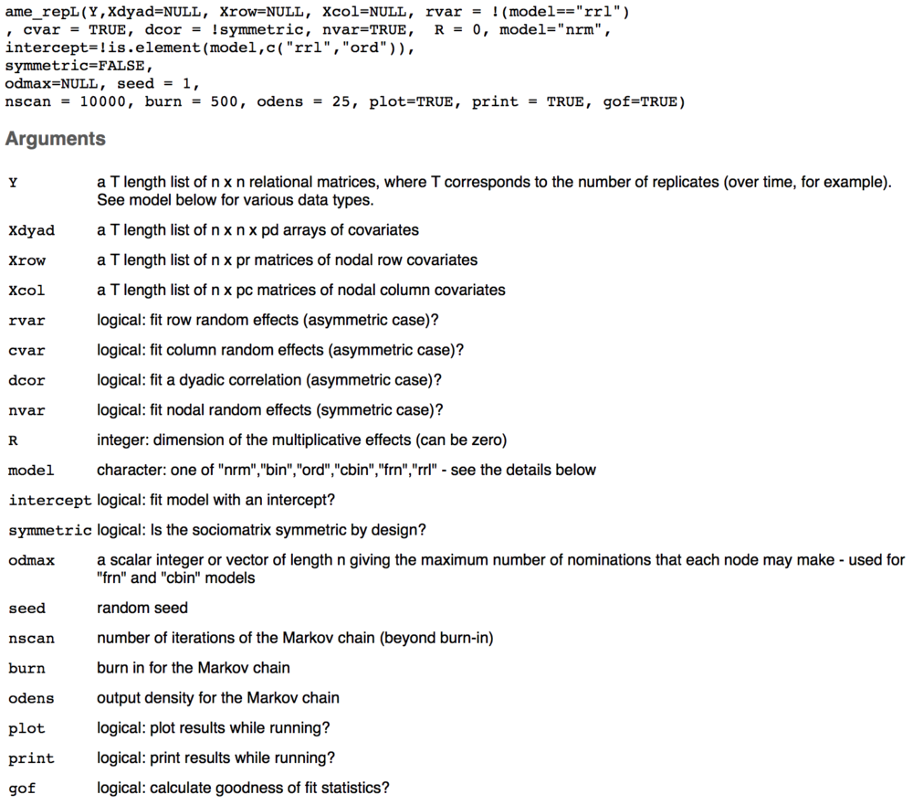

## Lets put it all together

- Undirected, `symmetric=TRUE`, binary, `model='bin'`, longitudinal AME model with actor random effects, `nvar=TRUE`, and a two dimensional multiplicative effect, `R=2`.

```r
fit=ame_repL(Y=yL, Xdyad=xDyadL, Xrow=xNodeL, Xcol=NULL,
      nvar=TRUE, R=2,
      model="bin",symmetric=TRUE,
      burn=500,nscan=1000,odens=10,
      plot=FALSE, print=FALSE,
      seed=6886 # ALWAYS SET A SEED
      )
```

```r
load('~/Dropbox/Research/netsMatter/replications/example/outputData/model_k2.rda')
```

## The output

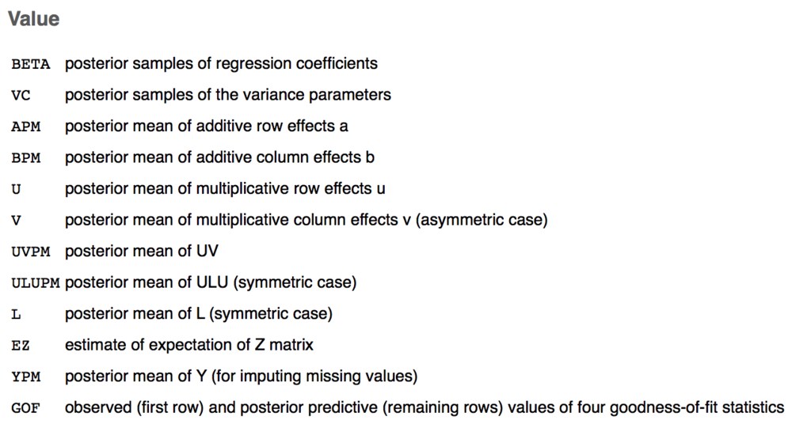

## First step…did the model converge

```r
fit$BETA[1:3,]
```

```
##      intercept  lgdp.node   polity.node      .dyad
## [1,] -5.686503 0.07370504 -0.0033490950 -0.4557089
## [2,] -6.715176 0.09451995 -0.0060325755 -0.4717781
## [3,] -5.696598 0.07301565 -0.0003914305 -0.4412825
```

```r
library(reshape2) ; library(ggplot2)

beta = data.frame(fit$BETA) ; names(beta)[ncol(beta)] = 'distance'
beta$iter = 1:nrow(beta)*10

ggBeta = reshape2::melt(beta,id='iter')
ggplot(ggBeta, aes(x=iter,y=value)) +
    geom_line() +
    facet_wrap(~variable,nrow=2,scales='free_y')
```

## First step…did the model converge

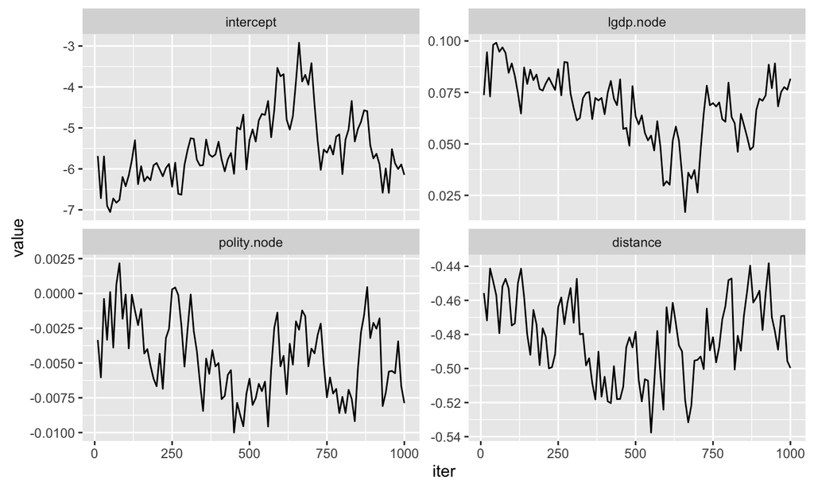

## Are we capturing the dependencies in our data?

- Lets find out by drawing from the posterior predictive distribution of our model

```r
fit$GOF[1:3,]
```

```
##     sd.rowmean sd.colmean dyad.dep   triad.dep
## obs 0.02172208 0.02172208        1 0.013502413
##     0.01755859 0.01755859        1 0.006830483
##     0.01732897 0.01732897        1 0.012752574
```

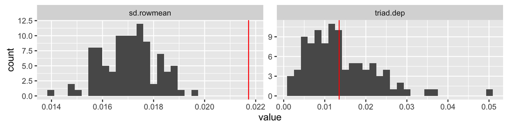

## Parameter estimates

```r
library(magrittr) # so it's easier to see
summStats = function(x){ c(mu=mean(x), sd=sd(x), quantile(x, probs=c(0.025,0.975)))  }

fit$BETA %>% apply(., 2, summStats) %>% round(., 3) %>% t(.)
```

```
##                 mu    sd   2.5%  97.5%
## intercept   -5.479 0.848 -6.793 -3.608
## lgdp.node    0.068 0.017  0.030  0.096
## polity.node -0.005 0.003 -0.009  0.000
## .dyad       -0.482 0.023 -0.523 -0.441
```

- You would then compare these with the corresponding GLM model.

## Visualizing third order dependence

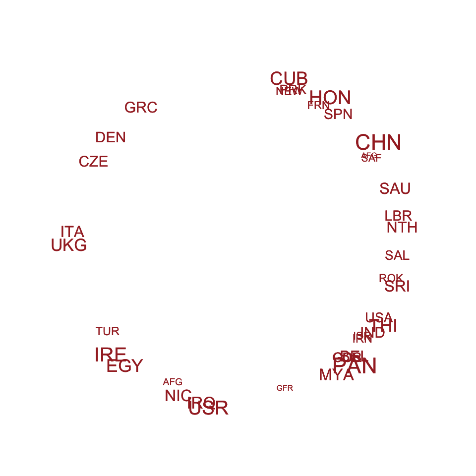

```r
circplot(Y=yL[[length(yL)]], U=fit$U, lcol='white')
```

## There will be a lot of models to run…

```r
# run ame in parallel # mcmc params
imps = 100000
brn = 50000
ods = 10
latDims = 1:4
seed=6886

# Run amen in parallel
library(doParallel) ; library(foreach)
cl=makeCluster(4) ; registerDoParallel(cl)
foreach(ii=1:length(latDims), .packages=c("amen")) %dopar% {
    ameFit = ame_repL(
        Y=yL,Xdyad=xDyadL,Xrow=xNodeL,Xcol=NULL, model="bin",symmetric=TRUE,
        R=latDims[ii],
        nscan=imps, seed=seed, burn=brn, odens=ods,
        plot=FALSE, print=FALSE)
    save(ameFit,
        file=paste0('~/Dropbox/netsMatter/replications/example/outputData/model_k',
            latDims[ii],'.rda'))
}
stopCluster(cl)
```

## Might need parallelization…

- because we will want to assess how varying k changes GOF

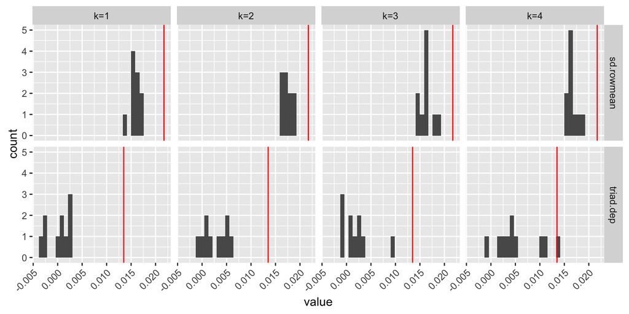

## and to assess performance

- In each year, randomly divide the \(n \times (n-1)\) data points into \(S\) sets of roughly equal size, letting \(s_{ij}\) be the set to which pair \(\{ij\}\) is assigned.
- For each \(s \in \{1, \ldots, S\}\):
  - Obtain estimates of the model parameters conditional on \(\{y_{ij} : s_{ij} \neq s\}\), the data on pairs not in set \(s\).
  - For pairs \(\{kl\}\) in set \(s\), let \(\hat y_{kl} = E[y_{kl} | \{y_{ij} : s_{ij} \neq s\}]\), the predicted value of \(y_{kl}\) obtained using data not in set \(s\).
- Code to perform this analysis for the example is shown in `git/netsMatter/code/example/runOutPerf.R`
- When we get out of sample results we will be evaluating across two metrics:
  - Sensitivity/Specificity & Precision/Recall

```
##     AUC    AUC (PR)
## k=3 "0.68" "0.08"
## k=2 "0.64" "0.05"
## k=1 "0.64" "0.03"
## k=4 "0.62" "0.02"
```

## Issues

- Any missingness in covariates inputted into AME automatically get turned into 0 … this is not good.
- We can get around this via imputing nodal and dyadic variables within AME
  - In this vein, I made a modified version of sbgcop that works over nodal and dyadic data…but we still need to incorporate this within the AME MCMC
  - also *within* because otherwise we'd have to run each model k times over different imputed datasets and use Rubin's rules to combine parameter estimates … problematic especially when it comes to third order deps
- **Computation time** … these models take a notable amount of time to converge
  - Mike's tower?
  - EC2 … though the costs can build

## Project Management

- Teams of two, each of you will be paired with someone experienced in AME
  - Dorff + Foster
  - Gallop + Liu
  - Ward + Roberts
  - Me + Tellez
- Claim the replications you want to do on Google sheets … whoever gets there first wins.
- **How many replications should we do?**
  - I propose two per team.
- **Timeline**
  - Decide on your two replication pieces by December 1
  - EACH TEAM SHOULD HAVE AT LEAST ONE REPLICATION MODEL RUNNING BY JANUARY 1
  - Paper draft end of January
- **What else?**

## Code + Data + Conversation

- We will be writing code on Git **ONLY**
- Input and output data will be stored on Dropbox **ONLY**
- We can converse on Slack
  - As you guys run into issues/questions/concerns we can raise them there and answer them in close to real-time